# Telco churn

Lina Marcela Quintero - Felipe Clement Santacruz

2019-06-19

# Carga de datos

```r
data_raw <- read.csv("data.csv")

colnames(data_raw) <- tolower(colnames(data_raw))

str(data_raw)
```

```
## 'data.frame':    23162 obs. of  9 variables:
##  $ estado            : Factor w/ 2 levels "RETIRADO","VINCULADO": 2 2 1 1 1 2 1 1 2 1 ...
##  $ ingresos          : int  4074840 8574088 795993 8115015 8187499 7250225 7256758 3262245 7281977 874177 ...
##  $ casa              : num  8.83e+08 1.74e+09 9.50e+07 8.30e+07 6.77e+08 ...
##  $ precio_dispositivo: num  1444153 2157661 452809 2617184 666069 ...
##  $ meses             : int  26 23 38 37 19 19 20 32 41 19 ...
##  $ duracion          : num  2.3 3.7 16.8 17.6 0 2.2 14.8 1.3 3 17.8 ...
##  $ sobrecargo        : num  11.2 0 350.6 230.9 131.5 ...
##  $ saldo_restante    : num  20.3 53.5 13.9 45.7 67.2 72 69.5 19 64.6 19.9 ...
##  $ satisfaccion      : num  1.76 3.36 8.36 8.96 8.81 ...
```

# Pregunta 1.1 - Exploracion de datos

Se revisa cada columna con el proposito de encontrar anomalias. Un resumen inicial es:

```r
summary(data_raw)
```

```
##        estado         ingresos            casa
##  RETIRADO :11665   Min.   : 150000   Min.   :8.000e+07
##  VINCULADO:11497   1st Qu.:2156296   1st Qu.:3.570e+08
##                    Median :6137553   Median :6.240e+08
##                    Mean   :4813115   Mean   :7.161e+08
##                    3rd Qu.:7347180   3rd Qu.:9.078e+08
##                    Max.   :9650000   Max.   :2.180e+09
##  precio_dispositivo     meses         duracion       sobrecargo
##  Min.   : 200000    Min.   : 0.0   Min.   : 0.00   Min.   :  0.00
##  1st Qu.: 657184    1st Qu.:14.0   1st Qu.: 2.10   1st Qu.: 12.57
##  Median :1237456    Median :24.0   Median :14.60   Median : 75.38
##  Mean   :1315340    Mean   :24.2   Mean   : 9.61   Mean   :110.06
##  3rd Qu.:1829581    3rd Qu.:34.0   3rd Qu.:16.10   3rd Qu.:201.55
##  Max.   :4700000    Max.   :79.0   Max.   :20.10   Max.   :411.17
##  saldo_restante    satisfaccion
##  Min.   :  0.00   Min.   :0.6136
##  1st Qu.: 15.20   1st Qu.:2.7055
##  Median : 37.65   Median :4.0645
##  Mean   : 42.99   Mean   :5.4808
##  3rd Qu.: 70.00   3rd Qu.:8.2682
##  Max.   :130.70   Max.   :9.6426
```

No se encuentran `NA` o valores fuera de rango (negativos, ilogicos). Se procede a explorar la distribucion de todas las columnas y se encuentra que las variables con mayor poder predictivo son `SOBRECARGO` y `SATISFACCION`; no existen anomalias en los datos.

## Estado

```r
data.frame(
  retirados = nrow(data_raw[(data_raw$estado == "RETIRADO"), ]) / nrow(data_raw),
  vinculados = nrow(data_raw[(data_raw$estado == "VINCULADO"), ]) / nrow(data_raw)
)
```

```
##   retirados vinculados
## 1 0.5036266  0.4963734
```

La distribucion de personas retiradas y vinculadas es casi igual, con el 50.36% de clientes retirados y el 49.63% vinculados.

## Ingresos

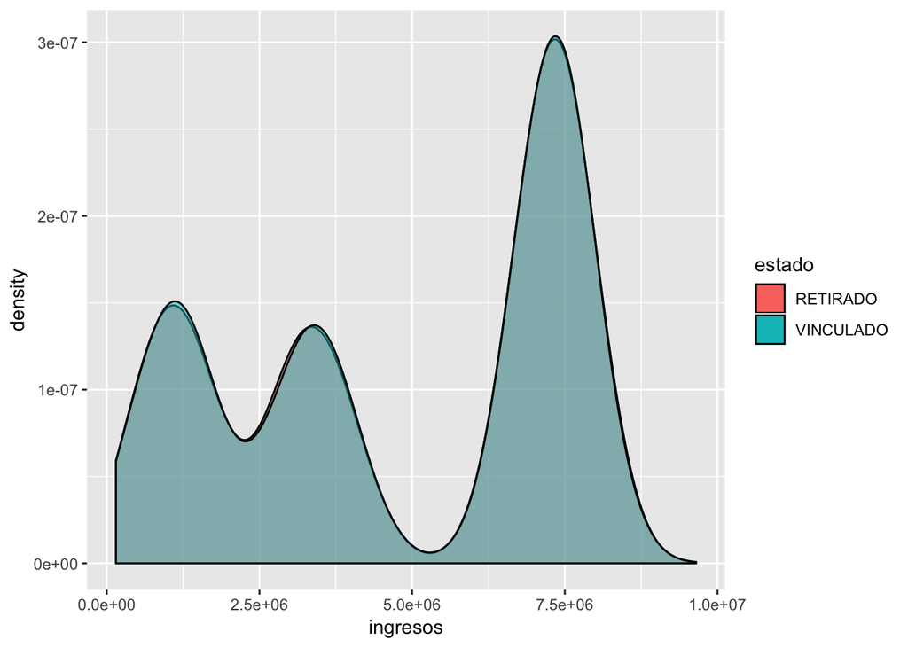

```r
ggplot(data_raw) + geom_density(aes(ingresos, group = estado, fill = estado, alpha = I(0.5)))
```

Esta variable parece segregar los clientes en 3 grupos diferentes.

## Casa

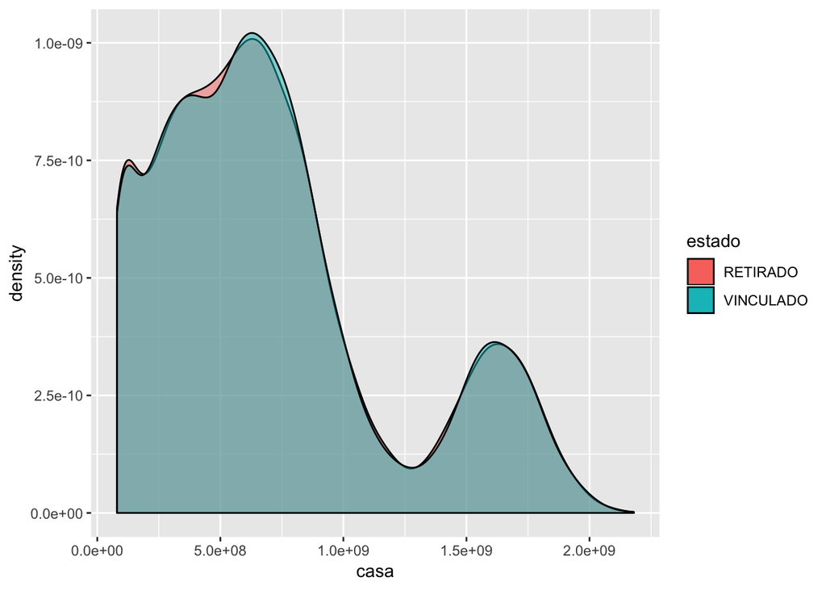

```r
ggplot(data_raw) + geom_density(aes(casa, group = estado, fill = estado, alpha = I(0.5)))
```

## Precio dispositivo

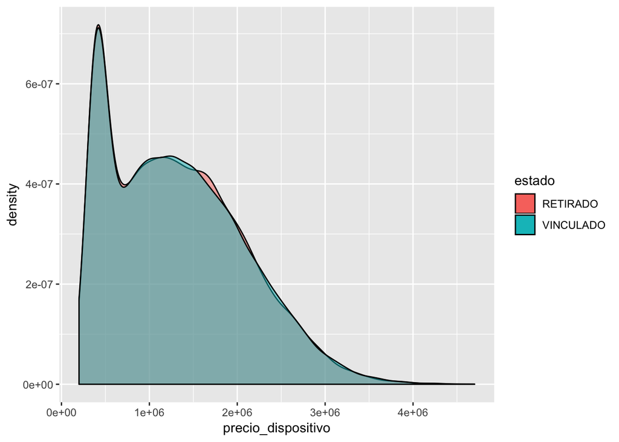

```r
ggplot(data_raw) + geom_density(aes(precio_dispositivo, group = estado, fill = estado, alpha = I(0.5)))
```

Parece que los datos tambien presentan 2 subconjuntos de clientes.

## Meses

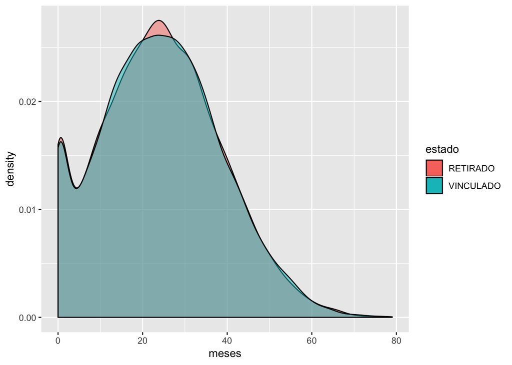

```r
ggplot(data_raw) + geom_density(aes(meses, group = estado, fill = estado, alpha = I(0.5)))
```

La mayoria de los clientes tienen una duracion mayor a 4 meses. No parece que hay correlacion entre el estado y los meses, es decir, los clientes que se van se quedan el mismo tiempo que los que se van.

## Duracion

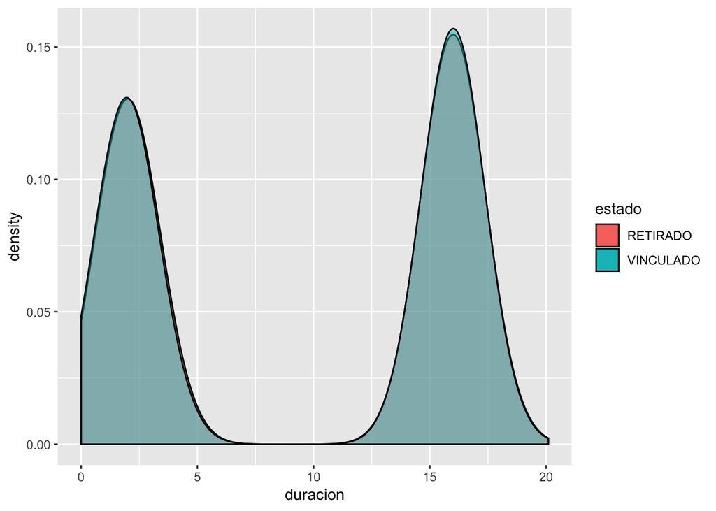

```r
ggplot(data_raw) + geom_density(aes(duracion, group = estado, fill = estado, alpha = I(0.5)))
```

Esta variable logra dividir los clientes en dos grupos casi perfectamente.

## Sobrecargo

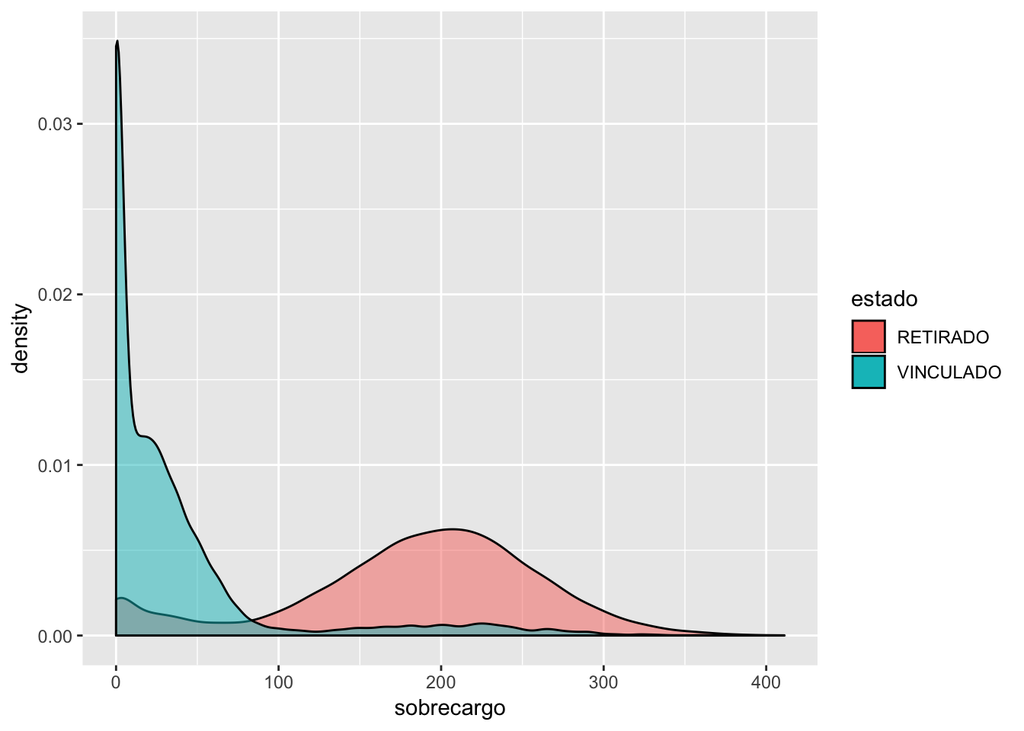

```r
ggplot(data_raw) + geom_density(aes(sobrecargo, group = estado, fill = estado, alpha = I(0.5)))
```

Esta variable logra dividir los clientes en dos grupos casi perfectamente. Presenta bastante poder predictivo, pues segrega bien entre estados.

## Saldo restante

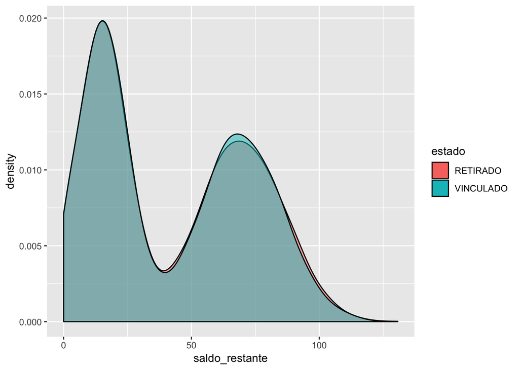

```r
ggplot(data_raw) + geom_density(aes(saldo_restante, group = estado, fill = estado, alpha = I(0.5)))
```

Esta variable logra dividir los clientes en dos grupos.

## Satisfaccion

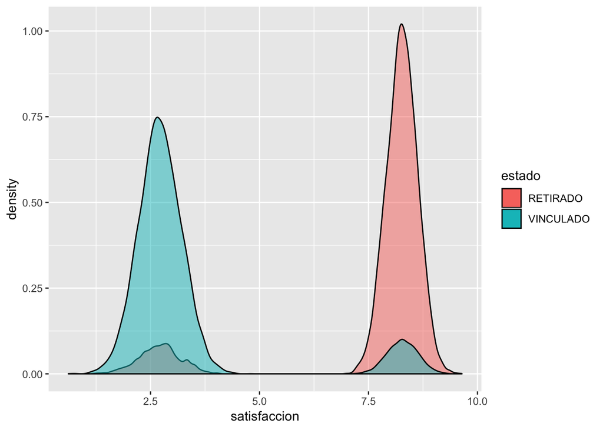

```r
ggplot(data_raw) + geom_density(aes(satisfaccion, group = estado, fill = estado, alpha = I(0.5)))
```

Esta variable logra dividir los clientes en dos grupos casi perfectamente. Presenta bastante poder predictivo, pues segrega bien entre estados.

# Pregunta 1.2 - Eliminacion de outliers

Se procede a eliminar observaciones con cualquiera de sus predictores por fuera de 4 desviaciones estabdar.

```r
are_outliers <- function(dt) {
  mean_data <- mean(dt)
  sd_data <- sd(dt)

  are_outliers <- abs((dt - mean_data) / sd_data) >= 4

  return(are_outliers)
}

data <- data_raw %>%
  filter_at(vars(-matches("estado")), all_vars(!are_outliers(.)))

nrow(data_raw) - nrow(data)
```

```
## [1] 4
```

Solo se eliminan 4 observaciones.

# Pregunta 1.3 - Correlacion entre variables

Se procede a analizar la correlacion entre los predictores.

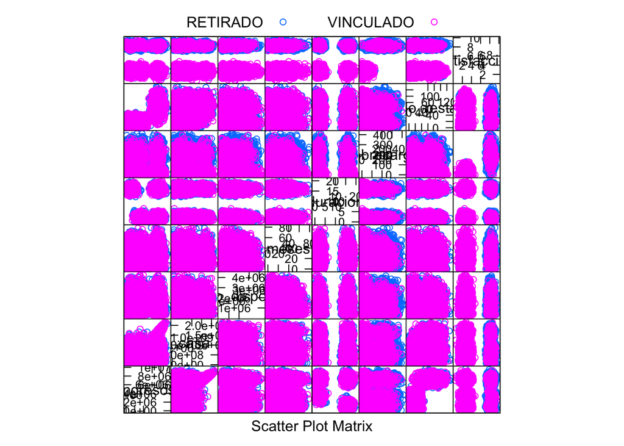

```r
featurePlot(
  x = data[, colnames(data) != "estado"],
  y = data$estado,
  plot = "pairs",
  auto.key = list(columns = 2)
)
```

Las variables no parecen estar (en parejas) correlacionadas de forma que permita discriminar (de manera significativa) entre clientes retirados y vinculados. Sin embargo, las variables `sobrecargo` y `satisfaccion` si parecen presentar una discriminacion mas alta como se observo anteriormente en el analisis univariado.

Desde el punto de vista de PCA esto podria indicar de que en los componentes principales obtenidos, la mayoria de la variacion va a ser explicada por `sobrecargo` y `satisfaccion`. Es posible que no sean necesarios muchos componentes principales debido a que las variables anteriormente mencionadas explican la variacion entre clientes con estado `RETIRADO` y `VINCULADO` bastante bien (teniendo en cuenta que esta variacion es la mas importante, pues el problema se trata de predecir).

# Pregunta 1.4 - Modelos predictivos

Se procede a escoger un protocolo de evaluacion, metricas de calidad de la prediccion y un modelo predictivo.

## a - Protocolo de evaluacion

Debido a que la cantidad de datos no es mucha –solo son 8 predictores y 23158 observaciones– se escoge 10-Fold cross-validation, con el proposito de:

- Entrenar los modelos con **todos** los datos
- Reducir la varianza de la estimacion del error de clasificacion de test, permitiendo escoger con mas certeza el modelo y parametros correctos
- Permitir una computacion del error de test que sea computacionalmente viable (en LOOCV se tendrian que entrenar mas de 23 mil modelos para cada parametro posible de todos los modelos)

## b - Metricas

Debido a que predecir los clientes con mayor probabilidad de irse es lo mas importante para este problema, se usara el **accuracy** como metrica para escoger un modelo durante el training. Es posible utilizar el accuracy y no el Kappa, debido a que las clases objetivo estan balanceadas y el baseline es del 50.36%. Adicional a esto, con el test set se tendra en cuenta el **recall** para escoger el modelo final, esto es debido a que lo mas importante es maximizar el porcentaje de personas que en realidad se retiraron y fueron predichas correctamente.

## c - Modelos

Para entrenar los modelos, se dividen los datos en training y test sets, con el proposito de tener datos con los cuales evaluar el modelo que no hayan sido parte del entrenamiento. De esta manera, se evitan los efectos del data leakage y se puede escoger el modelo despues de haber escogido varios en training.

```r
set.seed(1)
data_training_index <- createDataPartition(data$estado, p = 0.8, list = FALSE, times = 1)

data_training <- data[data_training_index, ]
data_test <- data[-data_training_index, ]

nrow(data_training)
```

```
## [1] 18528
```

```r
nrow(data_test)
```

```
## [1] 4630
```

Resultan dos datasets, el de entrenamiento con 18528 observaciones y el de test con 4630.

Adicionalmente, se habilita la computacion paralela, para optimizar el tiempo de ejecucion del training de los modelos.

```r
cl <- makePSOCKcluster(12)

registerDoParallel(cl)
```

### KNN

Se procede a entrenar un modelo con KNN, probando un valor de K entre 1 y 500, este limite maximo ha sido escogido debido a que para mas de 500 existen muchos empates y no es posible entrenar.

```r
seed <- rep(1, 500)
knn_seeds <- list(seed, seed, seed, seed, seed, seed, seed, seed, seed, seed, 1)

model_knn <- train(estado ~ ., data_training,
  method = "knn",
  trControl = trainControl(method = "repeatedcv", repeats = 1, number = 10, seeds = knn_seeds),
  tuneGrid = expand.grid(k = 1:500),
  preProcess = c("center", "scale")
)
```

Se grafica el resultado del accuracy y Kappa.

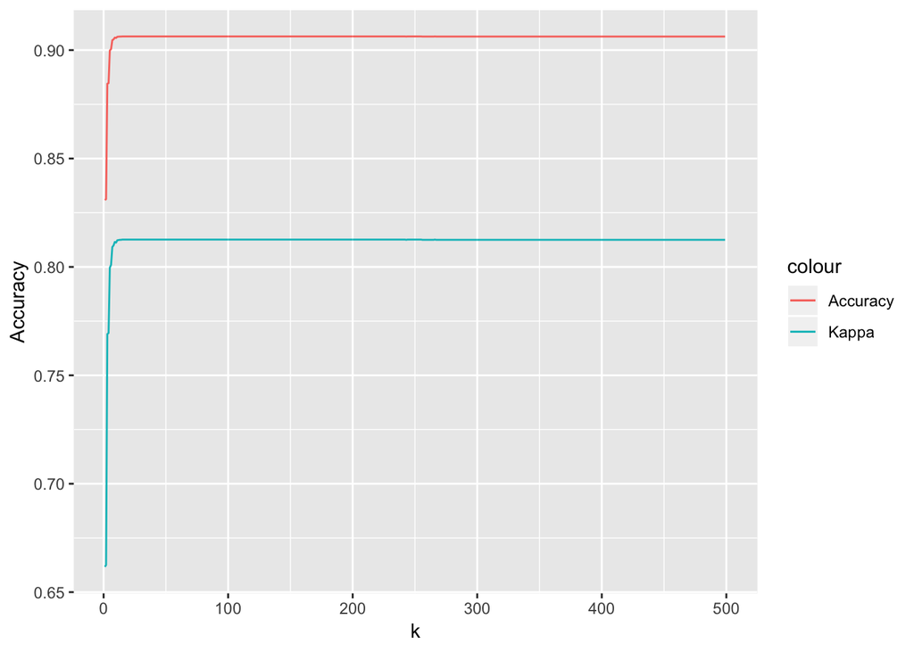

```r
ggplot(model_knn$results) +
  geom_line(aes(x = k, y = Accuracy, color = "Accuracy")) +
  geom_line(aes(x = k, y = Kappa, color = "Kappa"))
```

```r
knn_accuracy <- model_knn$results[which.max(model_knn$results$Accuracy), ]$Accuracy
knn_kappa <- model_knn$results[which.max(model_knn$results$Kappa), ]$Kappa

knn_accuracy
```

```
## [1] 0.9063041
```

```r
knn_kappa
```

```
## [1] 0.8126092
```

Se puede observar que ambos errores decrecen rapidamente hasta k = 15, donde luego el error se estabiliza. Se selecciona un valor de K de 15, pues es el parametro que maximiza el Kappa y accuracy simultaneamente, teniendo menor probabilidad de overfitting que un K grande.

### Arbol de decision

Se procede a entrenar un modelo de arbol de decision con el parametro de complejidad tomando valores entre 0 y 1, con pasos de 0.001.

```r
seed <- c(1)
tree_seeds <- list(seed, seed, seed, seed, seed, seed, seed, seed, seed, seed, 1)

model_tree <- train(estado ~ ., data_training,
  method = "rpart",
  trControl = trainControl(method = "repeatedcv", repeats = 1, number = 10, seeds = tree_seeds),
  tuneGrid = expand.grid(cp = seq(0, 1, 0.001))
)
```

Se grafica el resultado del accuracy y Kappa.

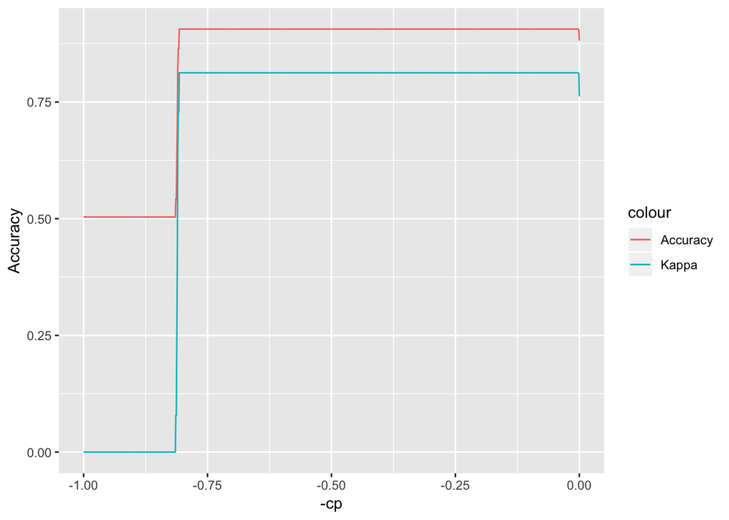

```r
ggplot(model_tree$results) +
  geom_line(aes(x = -cp, y = Accuracy, color = "Accuracy")) +
  geom_line(aes(x = -cp, y = Kappa, color = "Kappa"))
```

```r
tree_accuracy <- model_tree$results[model_tree$results$cp == model_tree$bestTune$cp, ]$Accuracy
tree_kappa <- model_tree$results[model_tree$results$cp == model_tree$bestTune$cp, ]$Kappa

tree_accuracy
```

```
## [1] 0.9063053
```

```r
tree_kappa
```

```
## [1] 0.8126112
```

### Regresion logistica

Se procede a entrenar un modelo de regresion logistica stepwise con AIC.

```r
seed <- c(1)
reg_seeds <- list(seed, seed, seed, seed, seed, seed, seed, seed, seed, seed, 1)

model_reg <- train(estado ~ ., data_training,
  method = "glmStepAIC",
  trControl = trainControl(method = "repeatedcv", repeats = 1, number = 10, verboseIter = TRUE, seeds = reg_seeds),
  preProcess = c("center", "scale")
)
```

```
## Start:  AIC=11754.41
## .outcome ~ ingresos + casa + precio_dispositivo + meses + duracion +
##     sobrecargo + saldo_restante + satisfaccion
##
##                      Df Deviance   AIC
## - precio_dispositivo  1    11736 11752
## - duracion            1    11737 11753
## - saldo_restante      1    11737 11753
## - ingresos            1    11737 11753
## - casa                1    11737 11753
## - meses               1    11738 11754
## <none>                     11736 11754
## - sobrecargo          1    11762 11778
## - satisfaccion        1    13501 13517
##
## Step:  AIC=11752.41
## .outcome ~ ingresos + casa + meses + duracion + sobrecargo +
##     saldo_restante + satisfaccion
##
##                  Df Deviance   AIC
## - duracion        1    11737 11751
## - saldo_restante  1    11737 11751
## - ingresos        1    11737 11751
## - casa            1    11737 11751
## - meses           1    11738 11752
## <none>                 11736 11752
## - sobrecargo      1    11762 11776
## - satisfaccion    1    13501 13515
##
## Step:  AIC=11750.88
## .outcome ~ ingresos + casa + meses + sobrecargo + saldo_restante +
##     satisfaccion
##
##                  Df Deviance   AIC
## - saldo_restante  1    11737 11749
## - ingresos        1    11737 11749
## - casa            1    11738 11750
## - meses           1    11739 11751
## <none>                 11737 11751
## - sobrecargo      1    11763 11775
```

[output cut: 24 more lines]

```
## .outcome ~ meses + sobrecargo + satisfaccion
##
##                Df Deviance   AIC
## - meses         1    11740 11746
## <none>               11738 11746
## - sobrecargo    1    11764 11770
## - satisfaccion  1    13504 13510
##
## Step:  AIC=11746.31
## .outcome ~ sobrecargo + satisfaccion
##
##                Df Deviance   AIC
## <none>               11740 11746
## - sobrecargo    1    11766 11770
## - satisfaccion  1    13506 13510
```

Se para el cluster de ejecucion paralela.

```r
stopCluster(cl)
```

```r
model_reg$results
```

```
##   parameter  Accuracy     Kappa  AccuracySD    KappaSD
## 1      none 0.9063053 0.8126112 0.007317528 0.01463794
```

```r
reg_accuracy <- model_reg$results$Accuracy
reg_kappa <- model_reg$results$Kappa

reg_accuracy
```

```
## [1] 0.9063053
```

```r
reg_kappa
```

```
## [1] 0.8126112
```

El resultado de esta regresion resulta en un modelo con las variables `sobrecargo` y `satisfaccion`, que fueron las dos variables identificadas anteriormente como las de mayor poder predictivo.

## d - Evaluacion

Los tres modelos tienen los siguientes accuracy y Kappa:

```r
data.frame(
  Method = c("KNN", "Gini tree", "Logistic regression"),
  Accuracy = c(knn_accuracy, tree_accuracy, reg_accuracy),
  Kappa = c(knn_kappa, tree_kappa, reg_kappa)
)
```

```
##                Method  Accuracy     Kappa
## 1                 KNN 0.9063041 0.8126092
## 2           Gini tree 0.9063053 0.8126112
## 3 Logistic regression 0.9063053 0.8126112
```

### KNN

```r
knn_predictions <- predict(object = model_knn, data_test)

knn_results <- confusionMatrix(knn_predictions, data_test$estado)
knn_results
```

```
## Confusion Matrix and Statistics
##
##            Reference
## Prediction  RETIRADO VINCULADO
##   RETIRADO      2084       197
##   VINCULADO      248      2101
##
##                Accuracy : 0.9039
##                  95% CI : (0.895, 0.9122)
##     No Information Rate : 0.5037
##     P-Value [Acc > NIR] : < 2e-16
##
##                   Kappa : 0.8078
##
##  Mcnemar's Test P-Value : 0.01778
##
##             Sensitivity : 0.8937
##             Specificity : 0.9143
##          Pos Pred Value : 0.9136
##          Neg Pred Value : 0.8944
##              Prevalence : 0.5037
##          Detection Rate : 0.4501
##    Detection Prevalence : 0.4927
##       Balanced Accuracy : 0.9040
##
##        'Positive' Class : RETIRADO
##
```

### Arbol de decision

```r
tree_predictions <- predict(object = model_tree, data_test)

tree_results <- confusionMatrix(tree_predictions, data_test$estado)
tree_results
```

```
## Confusion Matrix and Statistics
##
##            Reference
## Prediction  RETIRADO VINCULADO
##   RETIRADO      2084       197
##   VINCULADO      248      2101
##
##                Accuracy : 0.9039
##                  95% CI : (0.895, 0.9122)
##     No Information Rate : 0.5037
##     P-Value [Acc > NIR] : < 2e-16
##
##                   Kappa : 0.8078
##
##  Mcnemar's Test P-Value : 0.01778
##
##             Sensitivity : 0.8937
##             Specificity : 0.9143
##          Pos Pred Value : 0.9136
##          Neg Pred Value : 0.8944
##              Prevalence : 0.5037
##          Detection Rate : 0.4501
##    Detection Prevalence : 0.4927
##       Balanced Accuracy : 0.9040
##
##        'Positive' Class : RETIRADO
##
```

### Regresion logistica

```r
reg_predictions <- predict(object = model_reg, data_test)

reg_results <- confusionMatrix(reg_predictions, data_test$estado)
reg_results
```

```
## Confusion Matrix and Statistics
##
##            Reference
## Prediction  RETIRADO VINCULADO
##   RETIRADO      2084       197
##   VINCULADO      248      2101
##
##                Accuracy : 0.9039
##                  95% CI : (0.895, 0.9122)
##     No Information Rate : 0.5037
##     P-Value [Acc > NIR] : < 2e-16
##
##                   Kappa : 0.8078
##
##  Mcnemar's Test P-Value : 0.01778
##
##             Sensitivity : 0.8937
##             Specificity : 0.9143
##          Pos Pred Value : 0.9136
##          Neg Pred Value : 0.8944
##              Prevalence : 0.5037
##          Detection Rate : 0.4501
##    Detection Prevalence : 0.4927
##       Balanced Accuracy : 0.9040
##
##        'Positive' Class : RETIRADO
##
```

Como se puede observar, los 3 modelos tienen exactamente la misma matriz de confusion, por lo tanto tendran el mismo accuracy, Kappa y recall. Escoger un modelo para este problema, en el cual la calidad de prediccion de los 3 modelos es igual, se reduce a la inferencia que se pueda hacer con el. De esta forma, el modelo preferible es el arbol de decision, pues predice igual a los otros dos y sus resultados se pueden interpretar facilmente, permitiendo al negocio tomas decisiones en base a su estructura.

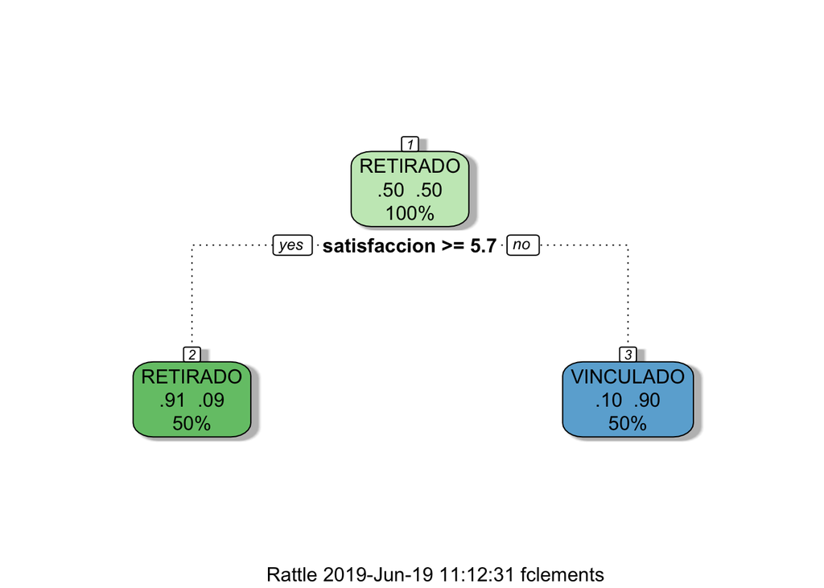

```r
fancyRpartPlot(model_tree$finalModel)
```

En este caso, el modelo que predice mejor el estado de un cliente es un decision stump de la variable `statisfaccion`, que particiona para un valor de 5.7. Para la puesta de este modelo en produccion, se entrenaria con el dataset completo, el modelo visualizado anteriormente solo fue entrenado con el training set.